# Material needed

Pablo Recio

2022-09-26

### **(Early) Environment manipulation**

**Eggs incubation**

- Containers - Where to find them
- Vermiculite or similar - What and where to find it
  - Both vermiculite and containers are in Wes Withen lab, in the incubators room
  - Bought more containers from Coles (arriving on 26/09)

**CORT supplementation**

- CORT - Where to find it
- Vehicle - What and where to find it
- Pippetes or similar to apply solution - What and where to find them
- Gloves - Where to find them
  - All material found in Wes Withen

**Eggs incubation**

- Incubators - How to use them

### **Learning tasks**

**Spatial learning task**

- Terraria - How many do we need? Size? Should we by more? How many?
  - We may need 100 terraria:

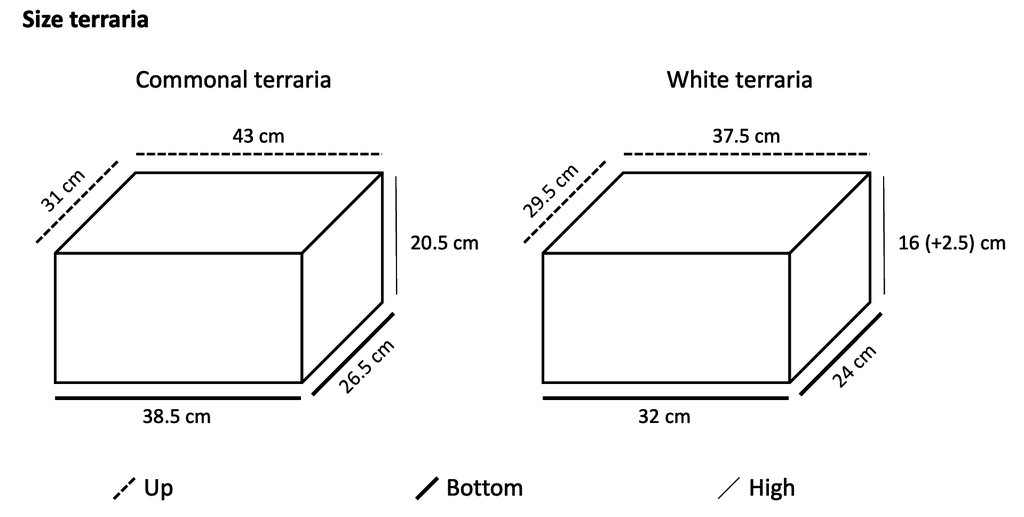

**Visual-reversal learning task**

- Terraria and cameras (Same as in Spatial learning task)
- Feeders - How many do we need? How to build them/do we have? Where?
  - There are painted blocks somewhere in the lab (search them), we may need more and a third colour
  - We will need 96 blocks per color - 288 in total
- Prey (reward) - How many? Should we use live prey, like crickets, or canned prey (prey in cue perception tests)?
  - We may need 3 per ind per trial, one of them being consumed = 5300 approx
  - Better use live prey - **Mealworms** instead of crickets

### **Other cognitive tests**

**Cue perception**

- Terraria and cameras (Same as in Spatial learning task)
- Containers - What to use? How many do we need? Where to find them?
  - Plastic glass or similar 2 per individual = 200 approx - **Found at *EcolPhysiol Lab* in Robertson Building**
  - Filter paper
- Prey - Canned food or live prey? How many needed?
  - 3 types of prey per ind = 100 preys/type
  - List of canned food available (Lab in Robertson Building 3rd green drawer under the table in the middle of the room):
    - Snails [6 cans]
    - XL crickets [1 can]
    - Grasshoppers [1 can]
    - XL Grasshoppers [1 can]
    - Fish [3 cans]
    - Silkworms [1 can]
    - Shrimps [1 can]
    - Artemia [1 can]
    - Mealworms [3 cans]
  - **Buy 30 cans of Mealworms, Crickets, Grashoppers, and Silkworms**

**Numerical abilities**

- Terraria and cameras (Same as in Spatial learning task)
- “Prey” - Could we use a kind of porridge made of flour and crickets or similar and shaped into small balls? That way we would be able to control continuous variables (volue, area, etc)
  - Porridge balls can work, but they need to be trained first

**Personality**

- Terraria and cameras (Same as in Spatial learning task)
- Refuges for *boldness antipredatory* trials - Where to find:
  - Shelters (What to use)
  - Ice for “cold” refuge
- Objects for *neophobia/neophilia* trials :
  - List of objects (in Robertson building lab, 2nd grey drawer between the fridges):
    - Orange earplugs - 2cm lenght
    - Dice with pink glue square - 1.8cm side approx
    - Red (3cm length), yellow (5cm), and/or white (6.7cm) plastic pin-like objects
    - Transparent marbles (1-1.5cm diameter) with red, blue and yellow feathers inside
    - Yellow and pink plasteline
- Filter paper, double-sided tape, sand or similar, cardboard or similar (FOR WALLS?)
  - Tape bought from Riotstores, check the rest of the material

### **HPA axis response**

**-**

### **Brain analyses**

**Dissection material**

- Scissors V
  - Dissection scope Get one to Wes Withen (for now)
  - Silicone pad V
  - Tweezers (see size) V
  - Dissection pins Buy
  - 2 Tweezers (see size) Buy one more
  - Scapel V
  - Blades Buy more on the internet
  - Dissection scissors V
  - Spatule Buy one

**-**